# EasyVisa Project

### Bagging with Hyper-Parameters

```python
Bagging_estimator=BaggingClassifier(random_state=1,estimator=DecisionTreeClassifier(class_weight="balanced",random_state=1))
Bagging_parameters={
    "n_estimators":np.arange(10,90,10),
    "max_samples":np.arange(3,10,1),
    "max_features":np.arange(0.1,0.9,0.1),
}
ssc_score=metrics.make_scorer(metrics.f1_score)
Bagging_Grid_obj=GridSearchCV(Bagging_estimator,Bagging_parameters,scoring=ssc_score,cv=5,n_jobs=-1)
Bagging_Grid_obj.fit(x_train,y_train)
Bagging_estimator=Bagging_Grid_obj.best_estimator_
Bagging_estimator.fit(x_train,y_train)
```

```
BaggingClassifier(estimator=DecisionTreeClassifier(class_weight='balanced',
                                                   random_state=1),
                  max_features=0.8, max_samples=8, n_estimators=80,
                  random_state=1)
```

```python
Bagging_estimator_train=check_model_performance(Bagging_estimator,x_train,y_train)
Bagging_estimator_train
```

|  | recall | accuracy | precision | f1_score |
| --- | --- | --- | --- | --- |
| 0 | 0.999245 | 0.668367 | 0.668389 | 0.800996 |

```python
Bagging_estimator_test=check_model_performance(Bagging_estimator,x_test,y_test)
Bagging_estimator_test
```

|  | recall | accuracy | precision | f1_score |
| --- | --- | --- | --- | --- |
| 0 | 0.999804 | 0.668367 | 0.668238 | 0.801067 |

*observation*

- The Accuracy score is decreased but the recall and f1_score has increased
- Bagging_estimator model had more bias to recall than accuracy and precision

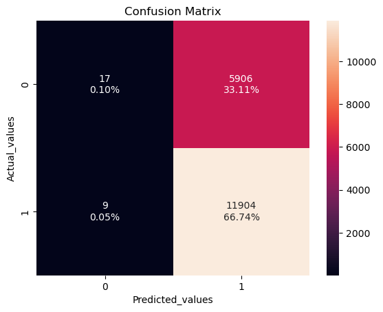

```python
checking_confution_matrix(Bagging_estimator,x_train,y_train)
```

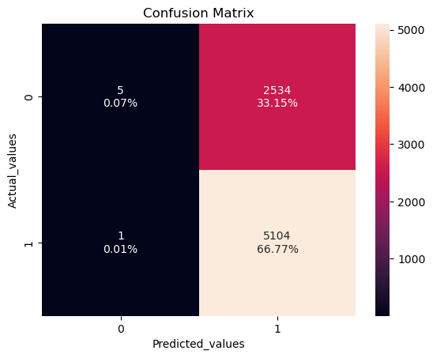

```python
checking_confution_matrix(Bagging_estimator,x_test,y_test)
```

*Observation*

- The Predicting the denied is very close to zero and TN are nearly zero this is not properly distrubuted

[figure not shown]

```python
feature_name=x_train.columns.to_list()
important=Bagging_estimator.feature_names_in_
indecies=np.argsort(important)
plt.barh(range(len(indecies)),important[indecies])
plt.yticks(range(len(indecies)),[feature_name[i] for i in indecies]);
plt.title("Imp Feature");
```

### Random Forest

- First with out hyper parameters
- Secound with hyper parameter

```python
rf_model= RandomForestClassifier(random_state=1,class_weight="balanced")
rf_model.fit(x_train,y_train)
```

```
RandomForestClassifier(class_weight='balanced', random_state=1)
```

```python
rf_model_train=check_model_performance(rf_model,x_train,y_train)
rf_model_train
```

|  | recall | accuracy | precision | f1_score |
| --- | --- | --- | --- | --- |
| 0 | 1.0 | 1.0 | 1.0 | 1.0 |

```python
rf_model_test=check_model_performance(rf_model,x_test,y_test)
rf_model_test
```

|  | recall | accuracy | precision | f1_score |
| --- | --- | --- | --- | --- |
| 0 | 0.848384 | 0.724359 | 0.764654 | 0.804346 |

*Observation*

- The model score for the test and train have much difference which lead to overfitting of the data
- The model trained more noise

```python
checking_confution_matrix(rf_model,x_train,y_train)
```

[output not shown]

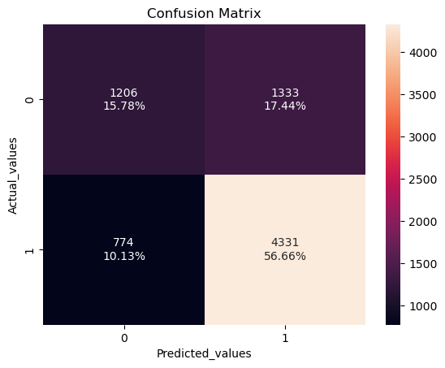

```python
checking_confution_matrix(rf_model,x_test,y_test)
```

*Observation*

- As per the model score the confustion matrix has given the similar score
- Due to over fitting of the data. The score in train are testing had much difference.

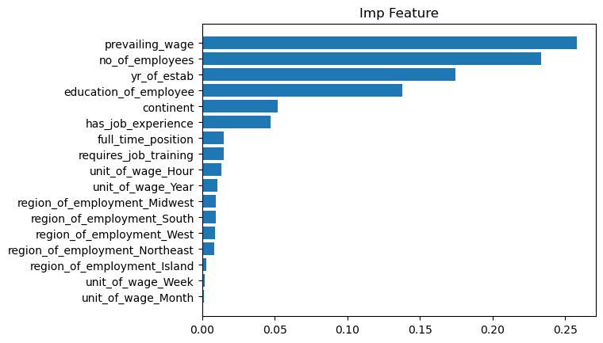

```python
feature_name=x_train.columns.to_list()
important=rf_model.feature_importances_
indecies=np.argsort(important)
plt.barh(range(len(indecies)),important[indecies])
plt.yticks(range(len(indecies)),[feature_name[i] for i in indecies]);
plt.title("Imp Feature");
```

### Random Forest With Hyper- Parameter

```python
rf_estimator=RandomForestClassifier(random_state=1,class_weight="balanced")
rf_parameters={
    "max_depth":np.arange(2,14,2),
    "min_samples_split":[2,7,8,9,10],
    "n_estimators":np.arange(80,200,20),
    "min_impurity_decrease":[0.001,0.01,0.1],
    "max_leaf_nodes":[4,6,8,10],
}
ssc_score=metrics.make_scorer(metrics.f1_score)
rf_grid_obj=GridSearchCV(rf_estimator,rf_parameters,scoring=ssc_score,cv=5,n_jobs=-1)
rf_grid_obj.fit(x_train,y_train)
rf_estimator_1=rf_grid_obj.best_estimator_
rf_estimator_1.fit(x_train,y_train)
```

```
RandomForestClassifier(class_weight='balanced', max_depth=6, max_leaf_nodes=8,
                       min_impurity_decrease=0.001, n_estimators=80,
                       random_state=1)
```

```python
rf_estimator_train=check_model_performance(rf_estimator_1,x_train,y_train)
rf_estimator_train
```

|  | recall | accuracy | precision | f1_score |
| --- | --- | --- | --- | --- |
| 0 | 0.763032 | 0.710866 | 0.795693 | 0.77902 |

```python
rf_estimator_test=check_model_performance(rf_estimator_1,x_test,y_test)
rf_estimator_test
```

|  | recall | accuracy | precision | f1_score |
| --- | --- | --- | --- | --- |
| 0 | 0.765132 | 0.71023 | 0.79358 | 0.779096 |

*Observation*

- The Random forest with the hyper parameter the score close to train
- This shows the model doen't have any over-fit or the noise and well trained

### Confused matrix for Random Forest

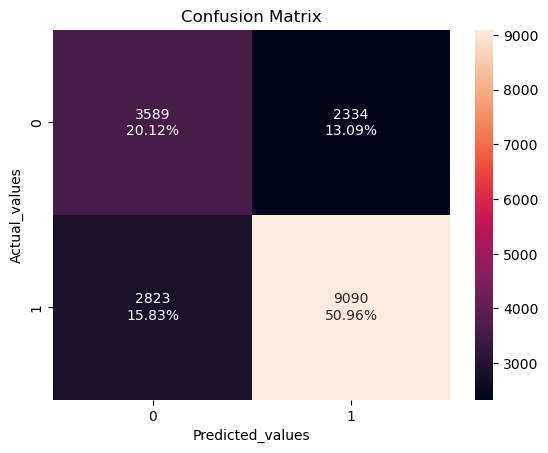

```python
checking_confution_matrix(rf_estimator_1,x_train,y_train)
```

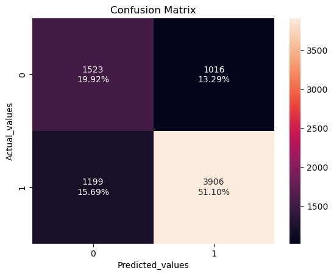

```python
checking_confution_matrix(rf_estimator_1,x_test,y_test)
```

*Observation*

- The random forest take huge time with hyperparameters
- It avoided the overfitting and noice
- Random forest models use a lot of memory.
- Using a large number of trees to make more accurate predictions can make the algorithm too slow for real-time prediction

### Important feature

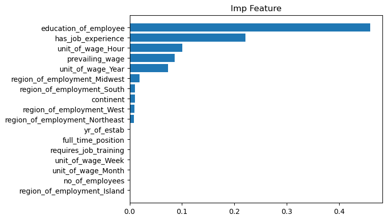

```python
feature_name=x_train.columns.to_list()
important=rf_estimator_1.feature_importances_
indecies=np.argsort(important)
plt.barh(range(len(indecies)),important[indecies])
plt.yticks(range(len(indecies)),[feature_name[i] for i in indecies]);
plt.title("Imp Feature");
```

### Boosting

- *AdaBoosting*
- *GradientBoosting*
- *XgBoosting*
- There are 3 Type of Boosting

### AdaBoosting

```python
ada_model = AdaBoostClassifier(random_state=1,estimator=RandomForestClassifier(random_state=1,class_weight="balanced"))
ada_model.fit(x_train,y_train)
```

```
AdaBoostClassifier(estimator=RandomForestClassifier(class_weight='balanced',
                                                    random_state=1),
                   random_state=1)
```

```python
ada_model_train=check_model_performance(ada_model,x_train,y_train)
ada_model_train
```

|  | recall | accuracy | precision | f1_score |
| --- | --- | --- | --- | --- |
| 0 | 1.0 | 1.0 | 1.0 | 1.0 |

```python
ada_model_test=check_model_performance(ada_model,x_test,y_test)
ada_model_test
```

|  | recall | accuracy | precision | f1_score |
| --- | --- | --- | --- | --- |
| 0 | 0.844466 | 0.722266 | 0.764362 | 0.80242 |

*Observation*

- The score for the adaBoosting with out the Hyperparamter are overfitting

```python
checking_confution_matrix(ada_model,x_train,y_train)
```

[output not shown]

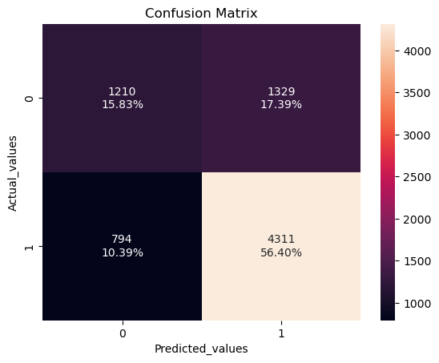

```python
checking_confution_matrix(ada_model,x_test,y_test)
```

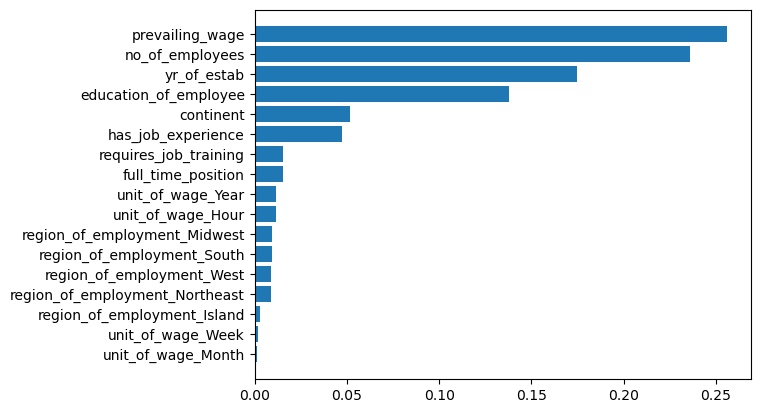

```python
feature_name=x_train.columns.to_list()
importance =ada_model.feature_importances_
ada_indecies=np.argsort(importance)
plt.barh(range(len(ada_indecies)),importance[ada_indecies])
plt.yticks(range(len(ada_indecies)),[feature_name[i] for i in ada_indecies]);
```

### AdaBoost with Hyper- parameter

```python
ada_estimator= AdaBoostClassifier(random_state=1)
ada_parameter={
     "n_estimators":[50,70,80,100],
    "learning_rate":[1.0,0.9,0.04,0.5],
    "estimator": [
        DecisionTreeClassifier(max_depth=2, random_state=1,class_weight="balanced"),
        DecisionTreeClassifier(max_depth=3, random_state=1,class_weight="balanced"),
    ],
}
ssc_score=metrics.make_scorer(metrics.f1_score)
Ada_Grid_obj=GridSearchCV(ada_estimator,ada_parameter,scoring=ssc_score,cv=5,n_jobs=-1)
Ada_Grid_obj.fit(x_train,y_train)
Ada_estimator_best=Ada_Grid_obj.best_estimator_
Ada_estimator_best.fit(x_train,y_train)
```

```
AdaBoostClassifier(estimator=DecisionTreeClassifier(class_weight='balanced',
                                                    max_depth=2,
                                                    random_state=1),
                   learning_rate=0.04, random_state=1)
```

```python
Ada_estimator_best_train=check_model_performance(Ada_estimator_best,x_train,y_train)
Ada_estimator_best_train
```

|  | recall | accuracy | precision | f1_score |
| --- | --- | --- | --- | --- |
| 0 | 0.778813 | 0.716528 | 0.793059 | 0.785872 |

```python
Ada_estimator_best_test=check_model_performance(Ada_estimator_best,x_test,y_test)
Ada_estimator_best_test
```

|  | recall | accuracy | precision | f1_score |
| --- | --- | --- | --- | --- |
| 0 | 0.780215 | 0.714547 | 0.789808 | 0.784982 |

*Observation*

- The score's did pretty good and the recall have done great in test

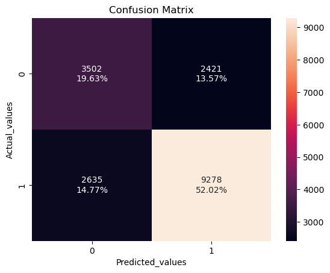

```python
checking_confution_matrix(Ada_estimator_best,x_train,y_train)
```

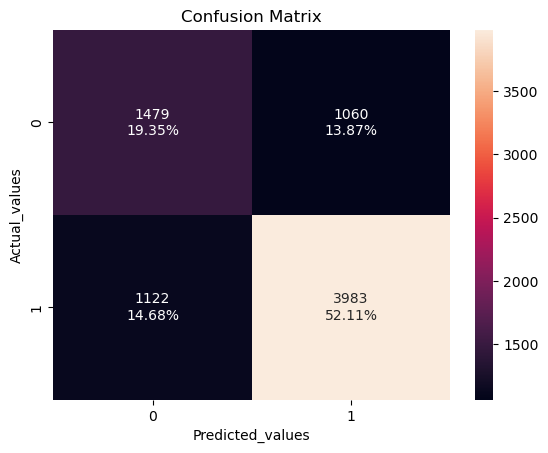

```python
checking_confution_matrix(Ada_estimator_best,x_test,y_test)
```

*Observation*

- The Ada boost have correctly predicted the FN,FP and the score for the training and testing are comparable.
- The 52.11 are visa approved

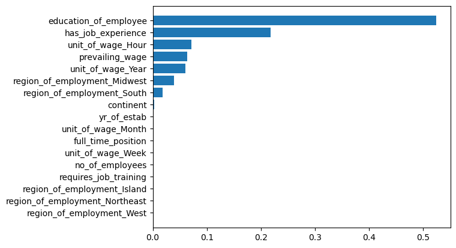

```python
feature_name=x_train.columns.to_list()
importance =Ada_estimator_best.feature_importances_
ada_indecies=np.argsort(importance)
plt.barh(range(len(ada_indecies)),importance[ada_indecies])
plt.yticks(range(len(ada_indecies)),[feature_name[i] for i in ada_indecies]);
```

*Observation*

- The feature compared to Random forest to adaboost they are reduced

### Gradient Boosting

- Building week sequential model into a single, more accurate predictive model.

```python
gb_model=GradientBoostingClassifier(random_state=1,init=AdaBoostClassifier(random_state=1))
gb_model.fit(x_train,y_train)
```

```
GradientBoostingClassifier(init=AdaBoostClassifier(random_state=1),
                           random_state=1)
```

```python
gb_model_train=check_model_performance(gb_model,x_train,y_train)
gb_model_train
```

|  | recall | accuracy | precision | f1_score |
| --- | --- | --- | --- | --- |
| 0 | 0.886846 | 0.757569 | 0.780223 | 0.830125 |

```python
gb_model_test=check_model_performance(gb_model,x_test,y_test)
gb_model_test
```

|  | recall | accuracy | precision | f1_score |
| --- | --- | --- | --- | --- |
| 0 | 0.880509 | 0.745421 | 0.77088 | 0.822056 |

*Observation*

- The model performed petty good. The scores are pretty close for the train and test results
- The model had not encounted the noise or the overfit or the underfit.

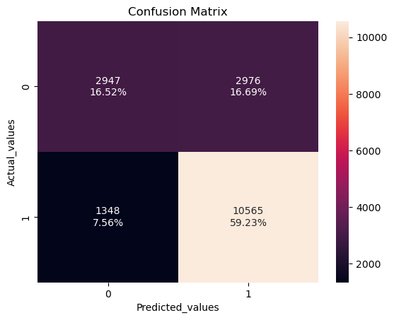

```python
checking_confution_matrix(gb_model,x_train,y_train)
```

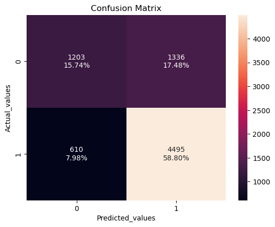

```python
checking_confution_matrix(gb_model,x_test,y_test)
```

*Observation*

- The FN and THE FP are in 7.98% and 17.48%
- With the Hyper parameter we will try to reduce the FP and FN

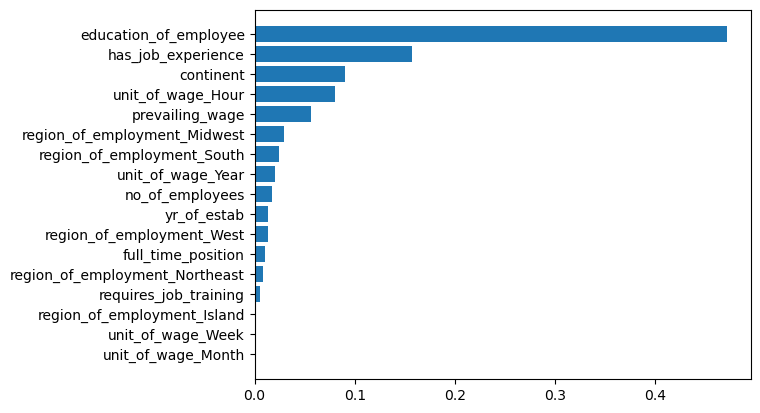

```python
feature_name=x_train.columns.to_list()
importance =gb_model.feature_importances_
ada_indecies=np.argsort(importance)
plt.barh(range(len(ada_indecies)),importance[ada_indecies])
plt.yticks(range(len(ada_indecies)),[feature_name[i] for i in ada_indecies]);
```

### Gradient-Boosting with hyper-parameter

```python
gb_estimator= GradientBoostingClassifier(random_state=1)
gb_parameters={
     "init": [AdaBoostClassifier(random_state=1),DecisionTreeClassifier(random_state=1,class_weight="balanced")],
    "n_estimators": np.arange(50,110,25),
    "learning_rate": [0.01,0.1,0.05],
    "subsample":[0.7,0.9],
    "max_features":[0.5,0.7,1],
}
ssc_score=metrics.make_scorer(metrics.f1_score)
gb_Grid_obj=GridSearchCV(gb_estimator,gb_parameters,scoring=ssc_score,cv=5,n_jobs=-1)
gb_Grid_obj.fit(x_train,y_train)
gb_estimator_best=gb_Grid_obj.best_estimator_
gb_estimator_best.fit(x_train,y_train)
```

```
GradientBoostingClassifier(init=AdaBoostClassifier(random_state=1),
                           max_features=0.5, n_estimators=50, random_state=1,
                           subsample=0.9)
```

```python
gb_estimator_train=check_model_performance(gb_estimator_best,x_train,y_train)
gb_estimator_train
```

|  | recall | accuracy | precision | f1_score |
| --- | --- | --- | --- | --- |
| 0 | 0.884076 | 0.753981 | 0.777901 | 0.827597 |

```python
gb_estimator_test=check_model_performance(gb_estimator_best,x_test,y_test)
gb_estimator_test
```

|  | recall | accuracy | precision | f1_score |
| --- | --- | --- | --- | --- |
| 0 | 0.877963 | 0.743982 | 0.770633 | 0.820804 |

*Observation*

- The well fit data with good overall score but recall and precision score reduced

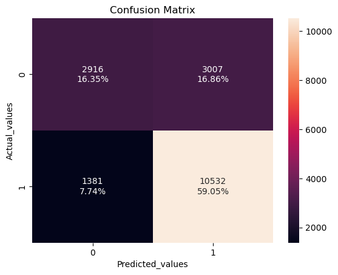

```python
checking_confution_matrix(gb_estimator_best,x_train,y_train)
```

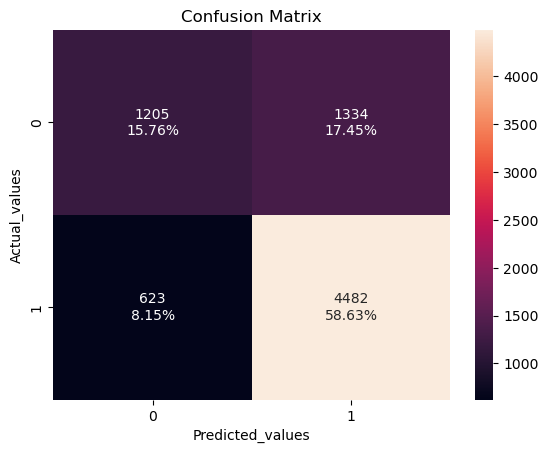

```python
checking_confution_matrix(gb_estimator_best,x_test,y_test)
```

*Observation*

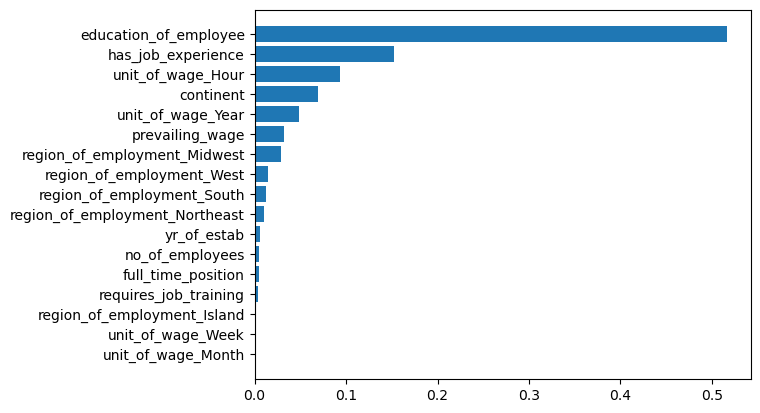

```python
feature_name=x_train.columns.to_list()
importance =gb_estimator_best.feature_importances_
ada_indecies=np.argsort(importance)
plt.barh(range(len(ada_indecies)),importance[ada_indecies])
plt.yticks(range(len(ada_indecies)),[feature_name[i] for i in ada_indecies]);
```

### XGBoosting

```python
xg_boosting=XGBClassifier(random_state=1,eval_metric='logloss',verbosity = 0)
xg_boosting.fit(x_train,y_train)
```

```
XGBClassifier(base_score=None, booster=None, callbacks=None,
              colsample_bylevel=None, colsample_bynode=None,
              colsample_bytree=None, device=None, early_stopping_rounds=None,
              enable_categorical=False, eval_metric='logloss',
              feature_types=None, gamma=None, grow_policy=None,
              importance_type=None, interaction_constraints=None,
              learning_rate=None, max_bin=None, max_cat_threshold=None,
              max_cat_to_onehot=None, max_delta_step=None, max_depth=None,
              max_leaves=None, min_child_weight=None, missing=nan,
              monotone_constraints=None, multi_strategy=None, n_estimators=None,
              n_jobs=None, num_parallel_tree=None, random_state=1, ...)
```

```python
xg_boosting_train=check_model_performance(xg_boosting,x_train,y_train)
checking_confution_matrix(gb_estimator_best,x_test,y_test)
```

[output not shown]

```python
xg_boosting_test=check_model_performance(xg_boosting,x_test,y_test)
xg_boosting_test
```

|  | recall | accuracy | precision | f1_score |
| --- | --- | --- | --- | --- |
| 0 | 0.85191 | 0.725144 | 0.763786 | 0.805445 |

### Observation

- The scores have much difference compared to train and test
- The data has collected more noise and outliers in the data

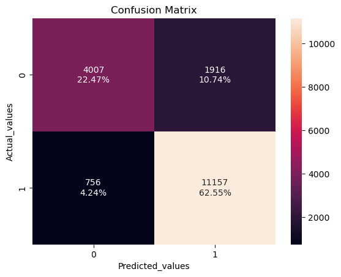

```python
checking_confution_matrix(xg_boosting,x_train,y_train)
```

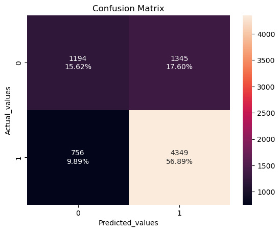

```python
checking_confution_matrix(xg_boosting,x_test,y_test)
```

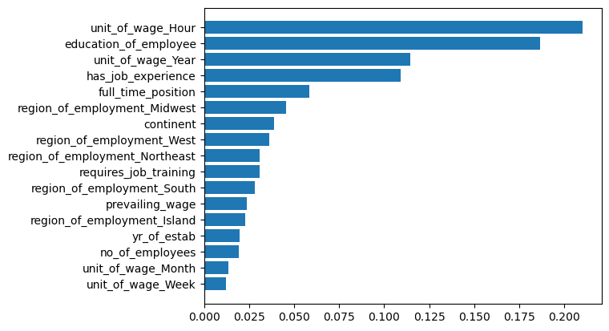

```python
feature_name=x_train.columns.to_list()
importance =xg_boosting.feature_importances_
ada_indecies=np.argsort(importance)
plt.barh(range(len(ada_indecies)),importance[ada_indecies])
plt.yticks(range(len(ada_indecies)),[feature_name[i] for i in ada_indecies]);
```

### XGBoosting with parameter

```python
xgb_tuned = XGBClassifier(random_state=1,eval_metric='logloss')

# Grid of parameters to choose from
## add from
param_xg_grid={'n_estimators':np.arange(50,110,25),
            'scale_pos_weight':[1,2,5],
            'learning_rate':[0.01,0.1,0.05],
            'gamma':[1,3],
            'subsample':[0.7,0.9]
}

# Type of scoring used to compare parameter combinations
acc_scorer = metrics.make_scorer(metrics.f1_score)

# Run the grid search
grid_obj = GridSearchCV(xgb_tuned, param_xg_grid,scoring=acc_scorer,cv=5)
grid_obj = grid_obj.fit(x_train, y_train)

# Set the clf to the best combination of parameters
xgb_tuned = grid_obj.best_estimator_

# Fit the best algorithm to the data.
xgb_tuned.fit(x_train, y_train)
```

```
XGBClassifier(base_score=None, booster=None, callbacks=None,
              colsample_bylevel=None, colsample_bynode=None,
              colsample_bytree=None, device=None, early_stopping_rounds=None,
              enable_categorical=False, eval_metric='logloss',
              feature_types=None, gamma=3, grow_policy=None,
              importance_type=None, interaction_constraints=None,
              learning_rate=0.05, max_bin=None, max_cat_threshold=None,
              max_cat_to_onehot=None, max_delta_step=None, max_depth=None,
              max_leaves=None, min_child_weight=None, missing=nan,
              monotone_constraints=None, multi_strategy=None, n_estimators=50,
              n_jobs=None, num_parallel_tree=None, random_state=1, ...)
```

```python
xgb_tuned_train=check_model_performance(xgb_tuned,x_train,y_train)
xgb_tuned_train
```

|  | recall | accuracy | precision | f1_score |
| --- | --- | --- | --- | --- |
| 0 | 0.898766 | 0.759251 | 0.776151 | 0.83297 |

```python
xgb_tuned_test=check_model_performance(xgb_tuned,x_test,y_test)
xgb_tuned_test
```

|  | recall | accuracy | precision | f1_score |
| --- | --- | --- | --- | --- |
| 0 | 0.887757 | 0.741758 | 0.763863 | 0.821163 |

*Observation*

- Comparing to all hyper model the xgboost score are best result with out any over fitting and noise

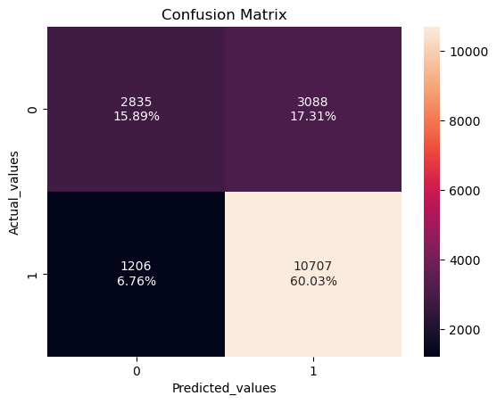

```python
checking_confution_matrix(xgb_tuned,x_train,y_train)
```

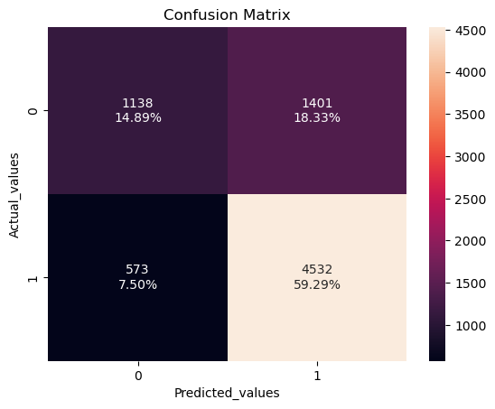

```python
checking_confution_matrix(xgb_tuned,x_test,y_test)
```

*Observation*

- The overcall FP and FN the values are well balanced

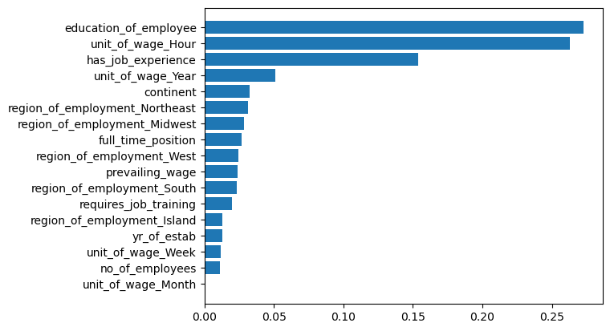

```python
feature_name=x_train.columns.to_list()
importance =xgb_tuned.feature_importances_
ada_indecies=np.argsort(importance)
plt.barh(range(len(ada_indecies)),importance[ada_indecies])
plt.yticks(range(len(ada_indecies)),[feature_name[i] for i in ada_indecies]);
```

### Stacking Model

```python
estimators=[('Decision Tree', Dtree_estimator),('Random Forest', rf_estimator_1),
           ('Gradient Boosting', gb_estimator_best)]
final_estimator=XGBClassifier(random_state=1)
```

```python
stacking_estimator=StackingClassifier(estimators=estimators, final_estimator=final_estimator,cv=5)
stacking_estimator.fit(x_train,y_train)
```

```
StackingClassifier(cv=5,
                   estimators=[('Decision Tree',
                                DecisionTreeClassifier(class_weight='balanced',
                                                       max_depth=4,
                                                       max_leaf_nodes=7,
                                                       min_impurity_decrease=0.001,
                                                       min_samples_split=3,
                                                       random_state=1)),
                               ('Random Forest',
                                RandomForestClassifier(class_weight='balanced',
                                                       max_depth=6,
                                                       max_leaf_nodes=8,
                                                       min_impurity_decrease=0.001,
                                                       n_estimators=80,
                                                       random_state=1)),
                               ('Gr...
                                                 feature_types=None, gamma=None,
                                                 grow_policy=None,
                                                 importance_type=None,
                                                 interaction_constraints=None,
                                                 learning_rate=None,
                                                 max_bin=None,
                                                 max_cat_threshold=None,
                                                 max_cat_to_onehot=None,
                                                 max_delta_step=None,
                                                 max_depth=None,
                                                 max_leaves=None,
                                                 min_child_weight=None,
                                                 missing=nan,
                                                 monotone_constraints=None,
                                                 multi_strategy=None,
                                                 n_estimators=None, n_jobs=None,
                                                 num_parallel_tree=None,
                                                 random_state=1, ...))
```

```python
stacking_estimator_train=check_model_performance(stacking_estimator,x_train,y_train)
stacking_estimator_train
```

|  | recall | accuracy | precision | f1_score |
| --- | --- | --- | --- | --- |
| 0 | 0.866868 | 0.747197 | 0.779396 | 0.820808 |

```python
stacking_estimator_test=check_model_performance(stacking_estimator,x_test,y_test)
stacking_estimator_test
```

|  | recall | accuracy | precision | f1_score |
| --- | --- | --- | --- | --- |
| 0 | 0.863075 | 0.738095 | 0.771764 | 0.81487 |

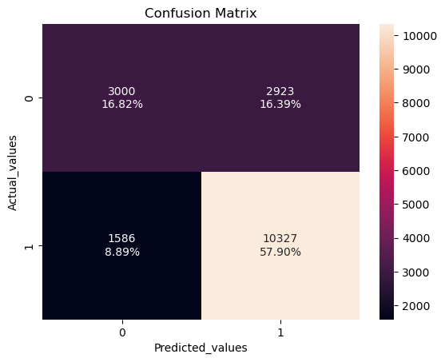

```python
checking_confution_matrix(stacking_estimator,x_train,y_train)
```

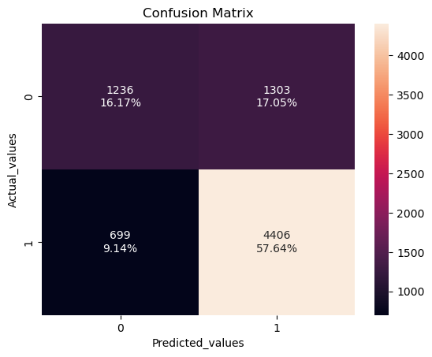

```python
checking_confution_matrix(stacking_estimator,x_test,y_test)
```

*Obseravtion*